# Red Wine Quality by Erin Pierson

> This report explores a dataset on red wine quality and its properties. We will try to identify which factors contribute to quality ratings.

```
##        X          fixed.acidity   volatile.acidity  citric.acid
##  Min.   :   1.0   Min.   : 4.60   Min.   :0.1200   Min.   :0.000
##  1st Qu.: 400.5   1st Qu.: 7.10   1st Qu.:0.3900   1st Qu.:0.090
##  Median : 800.0   Median : 7.90   Median :0.5200   Median :0.260
##  Mean   : 800.0   Mean   : 8.32   Mean   :0.5278   Mean   :0.271
##  3rd Qu.:1199.5   3rd Qu.: 9.20   3rd Qu.:0.6400   3rd Qu.:0.420
##  Max.   :1599.0   Max.   :15.90   Max.   :1.5800   Max.   :1.000
##  residual.sugar     chlorides       free.sulfur.dioxide
##  Min.   : 0.900   Min.   :0.01200   Min.   : 1.00
##  1st Qu.: 1.900   1st Qu.:0.07000   1st Qu.: 7.00
##  Median : 2.200   Median :0.07900   Median :14.00
##  Mean   : 2.539   Mean   :0.08747   Mean   :15.87
##  3rd Qu.: 2.600   3rd Qu.:0.09000   3rd Qu.:21.00
##  Max.   :15.500   Max.   :0.61100   Max.   :72.00
##  total.sulfur.dioxide    density             pH          sulphates
##  Min.   :  6.00       Min.   :0.9901   Min.   :2.740   Min.   :0.3300
##  1st Qu.: 22.00       1st Qu.:0.9956   1st Qu.:3.210   1st Qu.:0.5500
##  Median : 38.00       Median :0.9968   Median :3.310   Median :0.6200
##  Mean   : 46.47       Mean   :0.9967   Mean   :3.311   Mean   :0.6581
##  3rd Qu.: 62.00       3rd Qu.:0.9978   3rd Qu.:3.400   3rd Qu.:0.7300
##  Max.   :289.00       Max.   :1.0037   Max.   :4.010   Max.   :2.0000
##     alcohol         quality
##  Min.   : 8.40   Min.   :3.000
##  1st Qu.: 9.50   1st Qu.:5.000
##  Median :10.20   Median :6.000
##  Mean   :10.42   Mean   :5.636
##  3rd Qu.:11.10   3rd Qu.:6.000
##  Max.   :14.90   Max.   :8.000
```

```
## [1] 1599   13
```

```
##  [1] "X"                    "fixed.acidity"        "volatile.acidity"
##  [4] "citric.acid"          "residual.sugar"       "chlorides"
##  [7] "free.sulfur.dioxide"  "total.sulfur.dioxide" "density"
## [10] "pH"                   "sulphates"            "alcohol"
## [13] "quality"
```

```
##     X fixed.acidity volatile.acidity citric.acid residual.sugar chlorides
## 1   1           7.4             0.70        0.00            1.9     0.076
## 2   2           7.8             0.88        0.00            2.6     0.098
## 3   3           7.8             0.76        0.04            2.3     0.092
## 4   4          11.2             0.28        0.56            1.9     0.075
## 5   5           7.4             0.70        0.00            1.9     0.076
## 6   6           7.4             0.66        0.00            1.8     0.075
## 7   7           7.9             0.60        0.06            1.6     0.069
## 8   8           7.3             0.65        0.00            1.2     0.065
## 9   9           7.8             0.58        0.02            2.0     0.073
## 10 10           7.5             0.50        0.36            6.1     0.071
##    free.sulfur.dioxide total.sulfur.dioxide density   pH sulphates alcohol
## 1                   11                   34  0.9978 3.51      0.56     9.4
## 2                   25                   67  0.9968 3.20      0.68     9.8
## 3                   15                   54  0.9970 3.26      0.65     9.8
```

[output cut: 18 more lines]

# Univariate Plots Section

We just looked at some basic statistics for the data, now lets look at the quality distribution

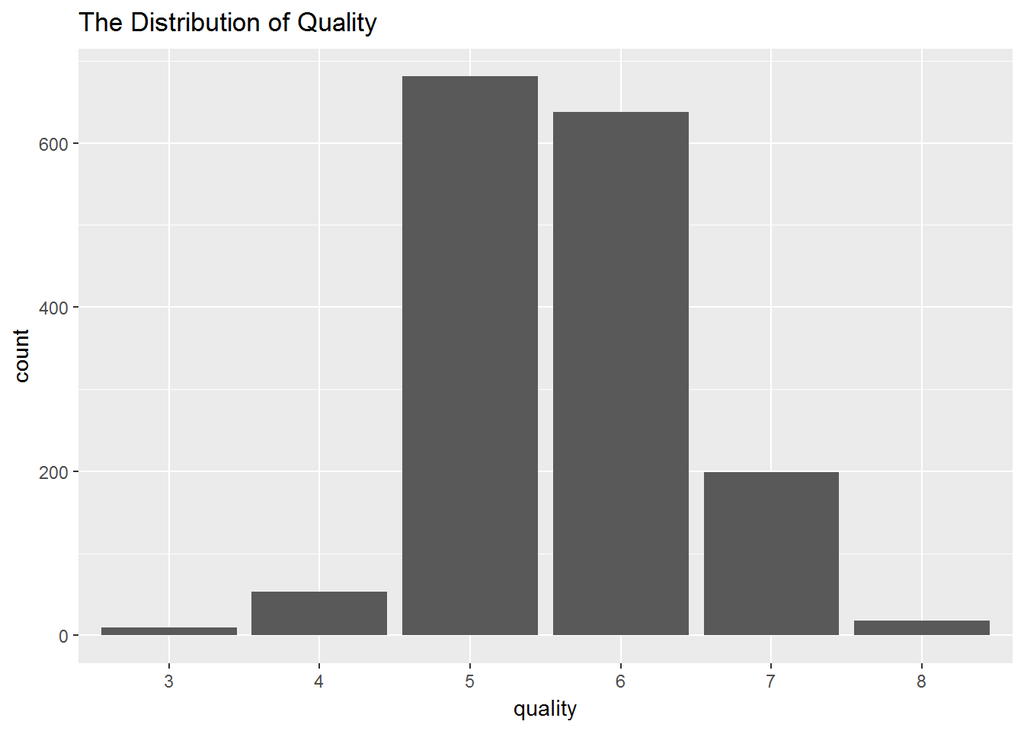

Now lets look at the distribution for all the variables

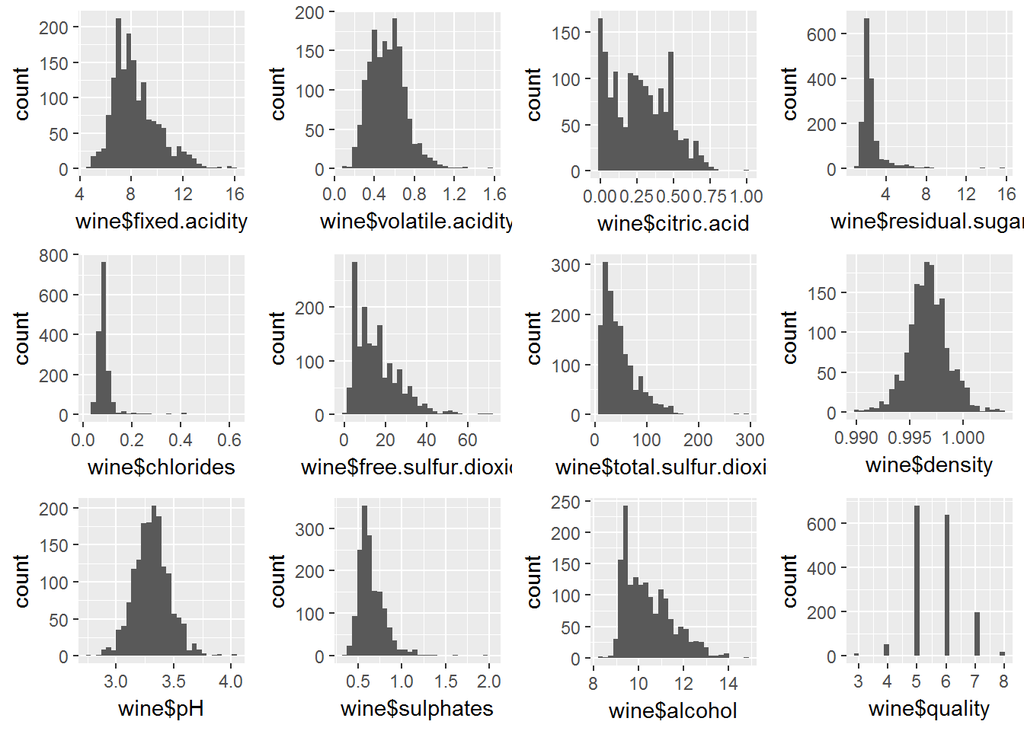

```
##    Min. 1st Qu.  Median    Mean 3rd Qu.    Max.
##    4.60    7.10    7.90    8.32    9.20   15.90
```

```
##    Min. 1st Qu.  Median    Mean 3rd Qu.    Max.
##  0.1200  0.3900  0.5200  0.5278  0.6400  1.5800
```

```
##    Min. 1st Qu.  Median    Mean 3rd Qu.    Max.
##   0.000   0.090   0.260   0.271   0.420   1.000
```

```
##    Min. 1st Qu.  Median    Mean 3rd Qu.    Max.
##   0.900   1.900   2.200   2.539   2.600  15.500
```

```
##    Min. 1st Qu.  Median    Mean 3rd Qu.    Max.
## 0.01200 0.07000 0.07900 0.08747 0.09000 0.61100
```

```
##    Min. 1st Qu.  Median    Mean 3rd Qu.    Max.
##    1.00    7.00   14.00   15.87   21.00   72.00
```

```
##    Min. 1st Qu.  Median    Mean 3rd Qu.    Max.
##    6.00   22.00   38.00   46.47   62.00  289.00
```

```
##    Min. 1st Qu.  Median    Mean 3rd Qu.    Max.
##  0.9901  0.9956  0.9968  0.9967  0.9978  1.0040
```

```
##    Min. 1st Qu.  Median    Mean 3rd Qu.    Max.
##   2.740   3.210   3.310   3.311   3.400   4.010
```

```
##    Min. 1st Qu.  Median    Mean 3rd Qu.    Max.
##  0.3300  0.5500  0.6200  0.6581  0.7300  2.0000
```

```
##    Min. 1st Qu.  Median    Mean 3rd Qu.    Max.
##    8.40    9.50   10.20   10.42   11.10   14.90
```

```
##    Min. 1st Qu.  Median    Mean 3rd Qu.    Max.
##   3.000   5.000   6.000   5.636   6.000   8.000
```

The majority of distributions skew slightly to the right. Let’s look at a couple in more detail.

# Sulphates

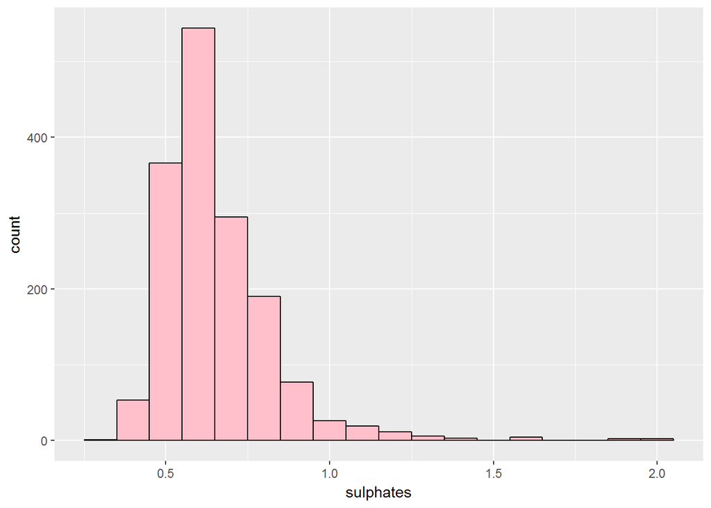

The distribution definitely looks a bit skewed so I’ll use log to normalize. Log sulphates

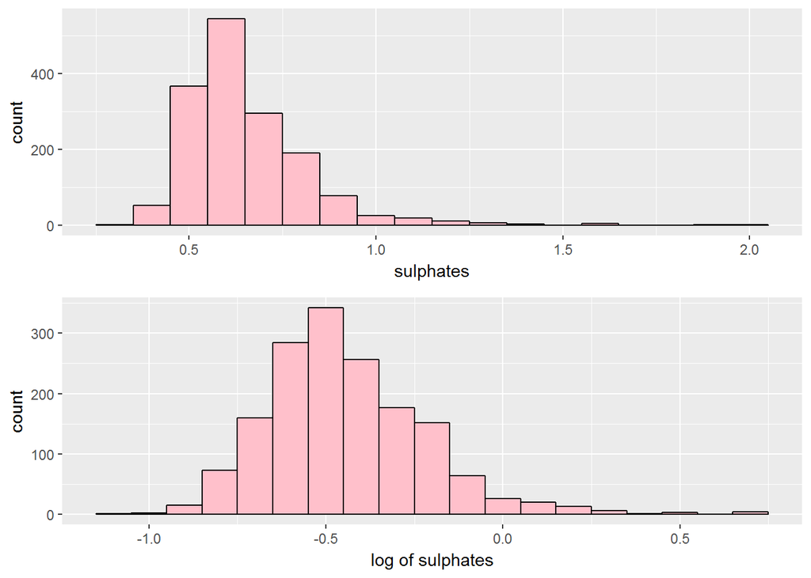

That looks a little better.

Now I’ll do the same with alcohol

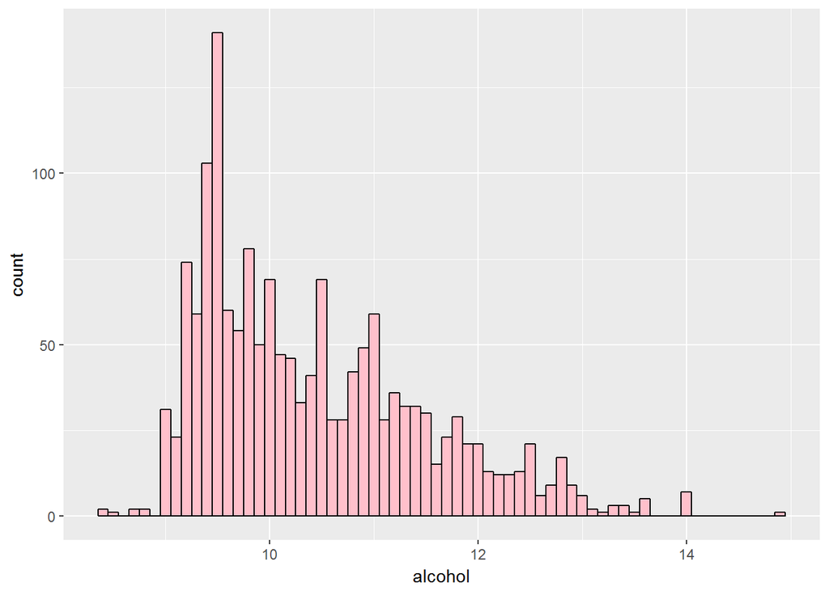

Log alcohol

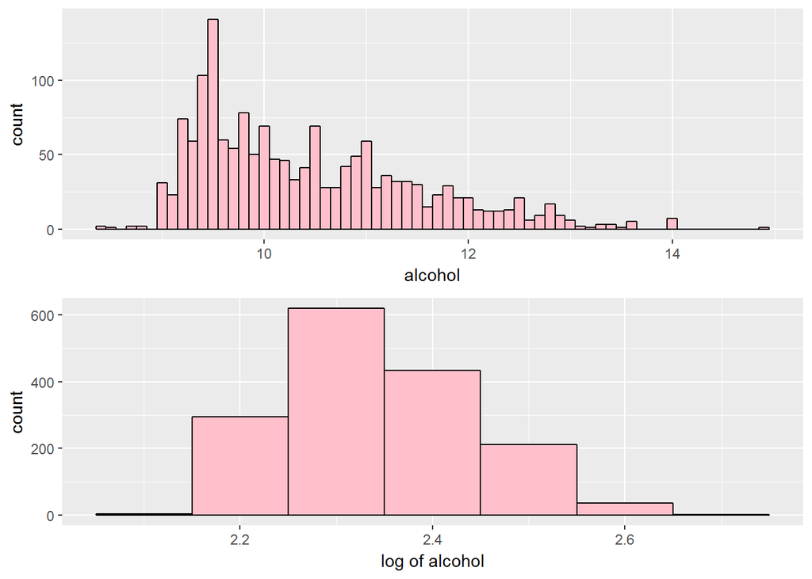

# Alcohol Content by Quality

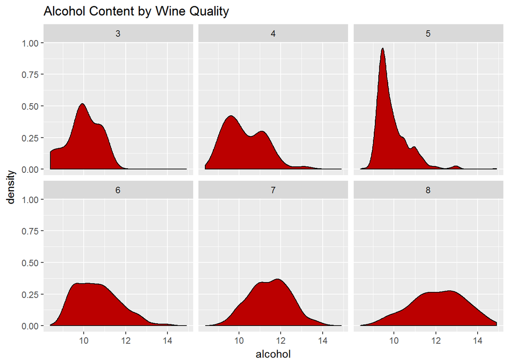

# Univariate Analysis

The dataset is comprised of 1599 observations and 13 variables. I am most interested in the relationship between sulphates and alcohol as they relate to wine quality. I am a wine drinker and I have always heard that high sulphate content translates into headaches/hangovers so I’m curious how that looks in the dataset.

I decided to add 3 new variables by grouping the quality rating into groups. Low(<=4), medium(5,6), and high(>=7).

Several of the distributions were skewed so I used the log function to attempt to normalize two of the variables(alcohol and sulphates). Once adjusted, we could see a clearer picture of how the data was distributed.

# Bivariate Plots Section

I’m going to use a correlation Matrix to see how the variables relate to each other.

```
##                      fixed.acidity volatile.acidity citric.acid
## fixed.acidity                1.000           -0.256       0.672
## volatile.acidity            -0.256            1.000      -0.552
## citric.acid                  0.672           -0.552       1.000
## residual.sugar               0.115            0.002       0.144
## chlorides                    0.094            0.061       0.204
## free.sulfur.dioxide         -0.154           -0.011      -0.061
## total.sulfur.dioxide        -0.113            0.076       0.036
## density                      0.668            0.022       0.365
## pH                          -0.683            0.235      -0.542
## sulphates                    0.183           -0.261       0.313
## alcohol                     -0.062           -0.202       0.110
## quality                      0.124           -0.391       0.226
##                      residual.sugar chlorides free.sulfur.dioxide
## fixed.acidity                 0.115     0.094              -0.154
## volatile.acidity              0.002     0.061              -0.011
## citric.acid                   0.144     0.204              -0.061
## residual.sugar                1.000     0.056               0.187
## chlorides                     0.056     1.000               0.006
## free.sulfur.dioxide           0.187     0.006               1.000
## total.sulfur.dioxide          0.203     0.047               0.668
## density                       0.355     0.201              -0.022
## pH                           -0.086    -0.265               0.070
## sulphates                     0.006     0.371               0.052
## alcohol                       0.042    -0.221              -0.069
## quality                       0.014    -0.129              -0.051
##                      total.sulfur.dioxide density     pH sulphates alcohol
## fixed.acidity                      -0.113   0.668 -0.683     0.183  -0.062
## volatile.acidity                    0.076   0.022  0.235    -0.261  -0.202
## citric.acid                         0.036   0.365 -0.542     0.313   0.110
## residual.sugar                      0.203   0.355 -0.086     0.006   0.042
## chlorides                           0.047   0.201 -0.265     0.371  -0.221
## free.sulfur.dioxide                 0.668  -0.022  0.070     0.052  -0.069
## total.sulfur.dioxide                1.000   0.071 -0.066     0.043  -0.206
## density                             0.071   1.000 -0.342     0.149  -0.496
## pH                                 -0.066  -0.342  1.000    -0.197   0.206
## sulphates                           0.043   0.149 -0.197     1.000   0.094
## alcohol                            -0.206  -0.496  0.206     0.094   1.000
## quality                            -0.185  -0.175 -0.058     0.251   0.476
##                      quality
## fixed.acidity          0.124
## volatile.acidity      -0.391
## citric.acid            0.226
## residual.sugar         0.014
## chlorides             -0.129
## free.sulfur.dioxide   -0.051
## total.sulfur.dioxide  -0.185
## density               -0.175
## pH                    -0.058
## sulphates              0.251
## alcohol                0.476
## quality                1.000
```

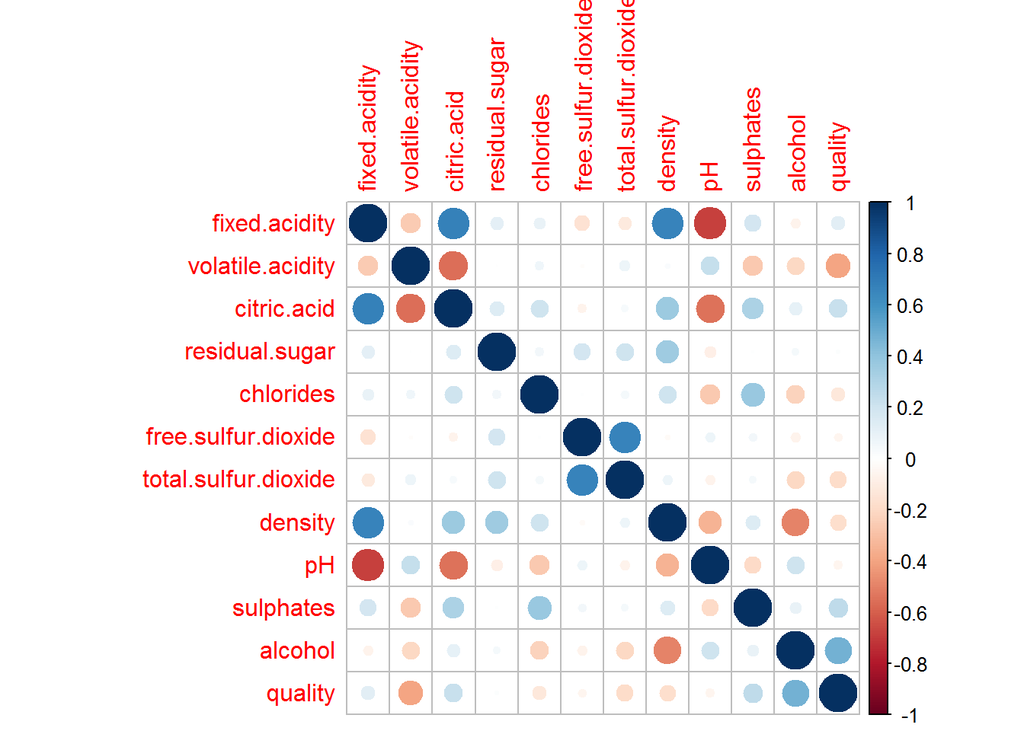

We see that quality has the highest positive correlation with alcohol(0.47), then sulphates(0.25), then citric acid(0.22), and finally fixed acid(0.124). It also has higher negative correlation with valatile acidity(-0.39),total sulfur dioxide(-0.185) and density(-0.175).

I’m going to look closer at the top two correlations:

Alcohol

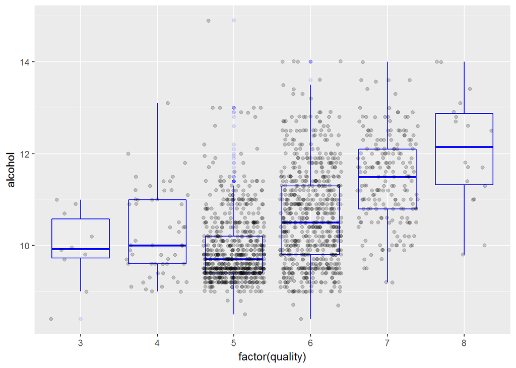

Sulphates

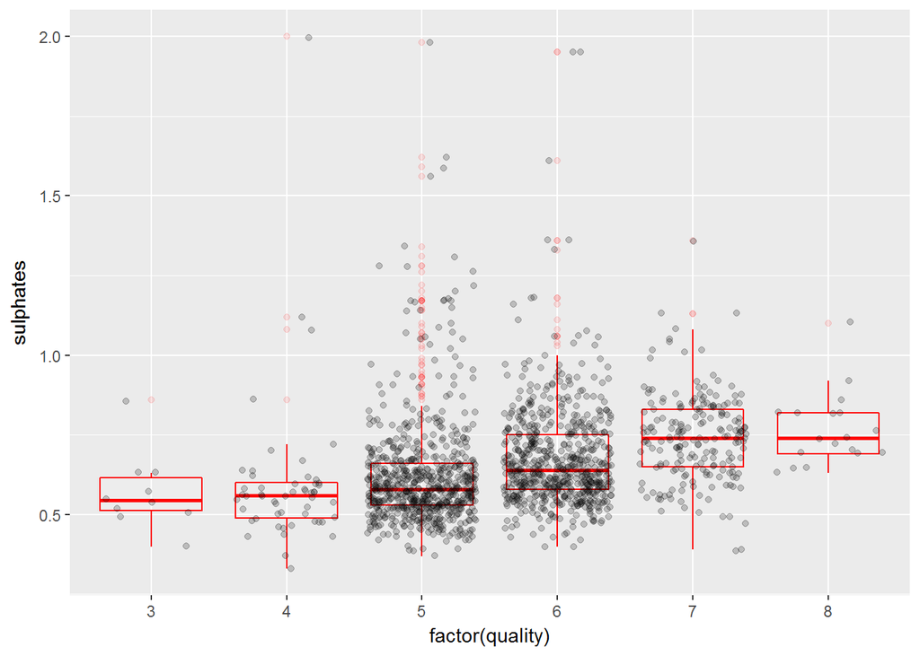

# Adding New Variables

I changed the quality variable type from and int to a factor to make it more useable for analysis. I created a new variable of quality.factor and added it to the dataframe.

Also, I created three categories of quality : high (>= 7), medium (5 and 6), and low (<=4).

We can see in the following boxplots how the different variables tend to move as the quality increases:

Alcohol, sulphates, citric.acid, and fixed.acidity tend to increase as quality increases.

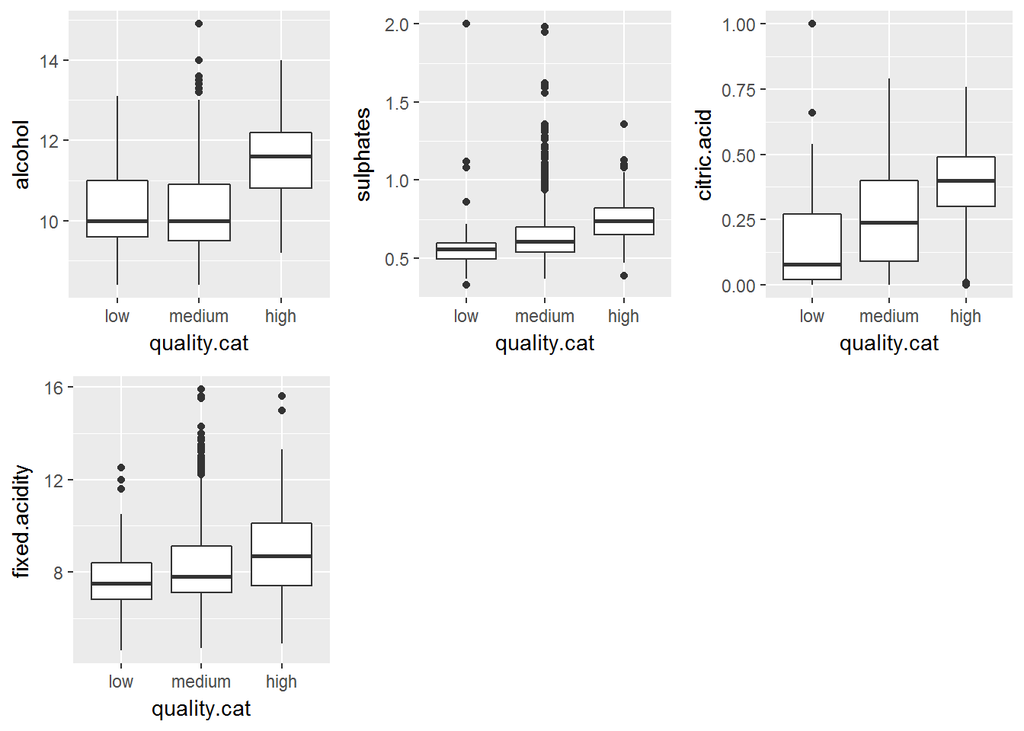

Volatile.acidity, pH, and density tend to decrease as quality increases.

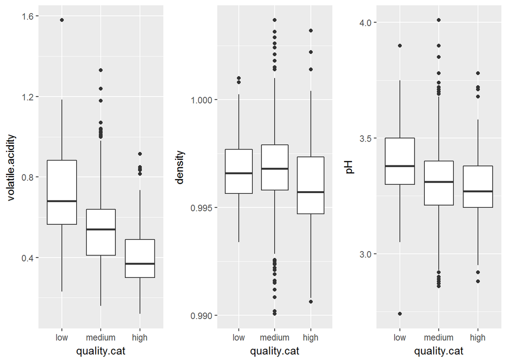

Chlorides, free.sulfur.dioxide, total.sulfur.dioxide, and residual.sugar do not tend to go up or down as quality increases.

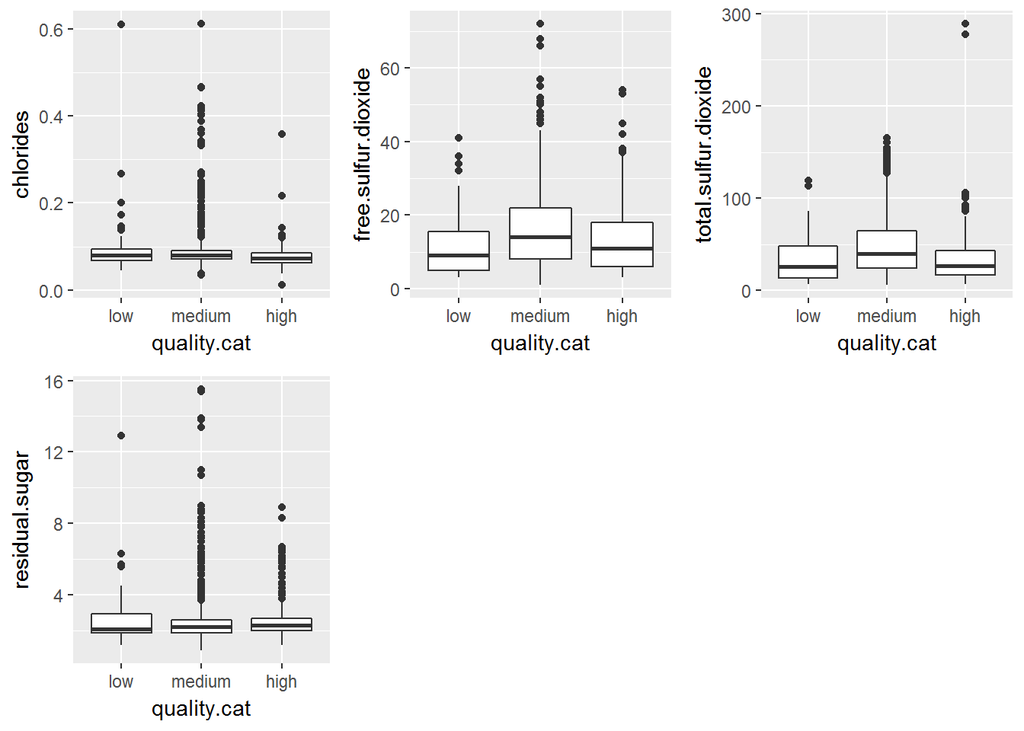

# Bivariate Analysis

Here we examine the categories as we increase the quality of wine. Alcohol, citric.acid, suphates, and fixed.acitidy all tend to be higher as the quality increases. The other categories are about the same or slightly lower as the quality increases. The alcohol level seemed to be the biggest influencer of quality. As the alcohol increased, the quality increased.

# Multivariate Plots Section

As noted above, alcohol,citric.acid, suphates, and fixed.acidity appear to have some sort of correlation to quallity.

Let’s look at how the combination of alcohol and sulphates affect the quality.

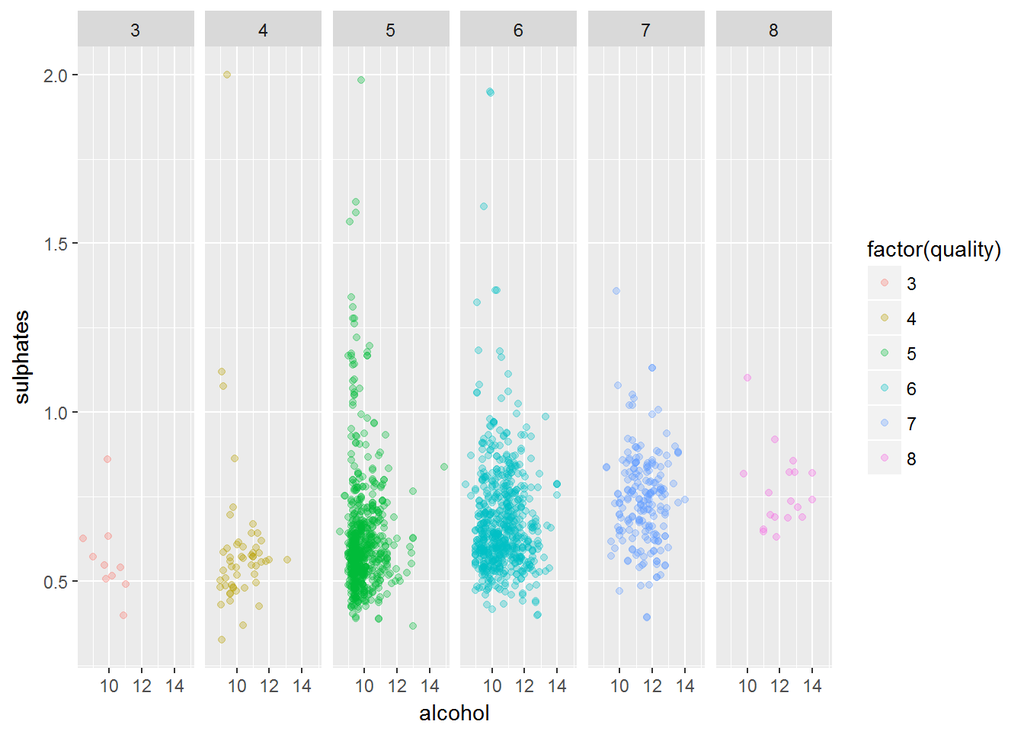

Next, citric acid and alcohol.

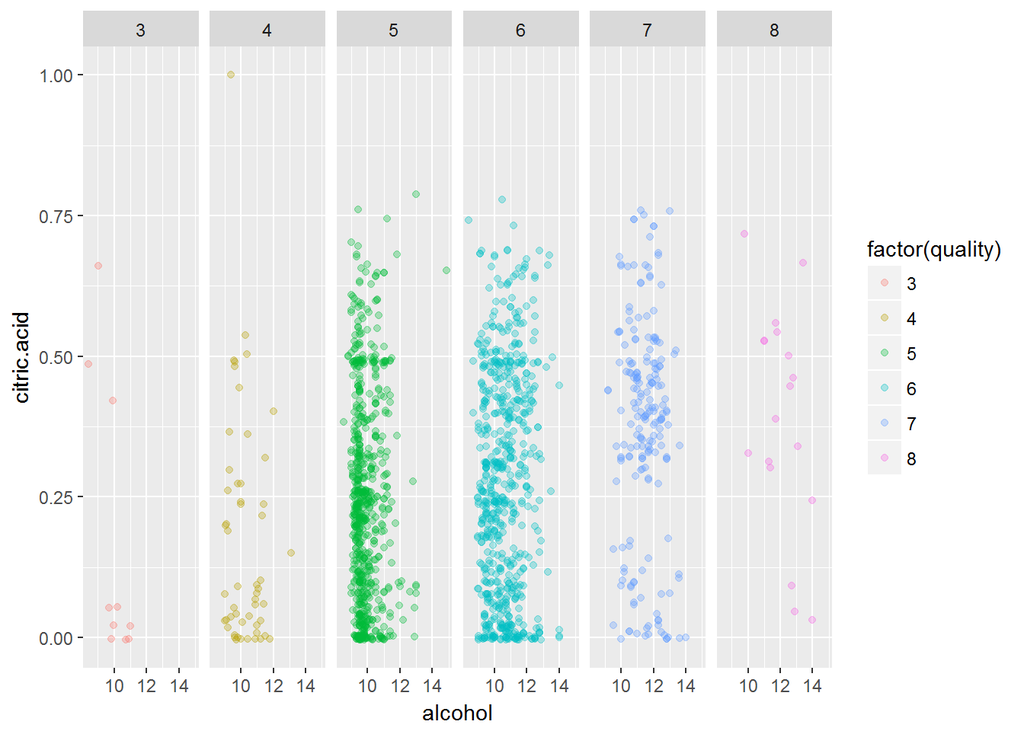

Let’s take alcohol out of the equation and just look at the acids

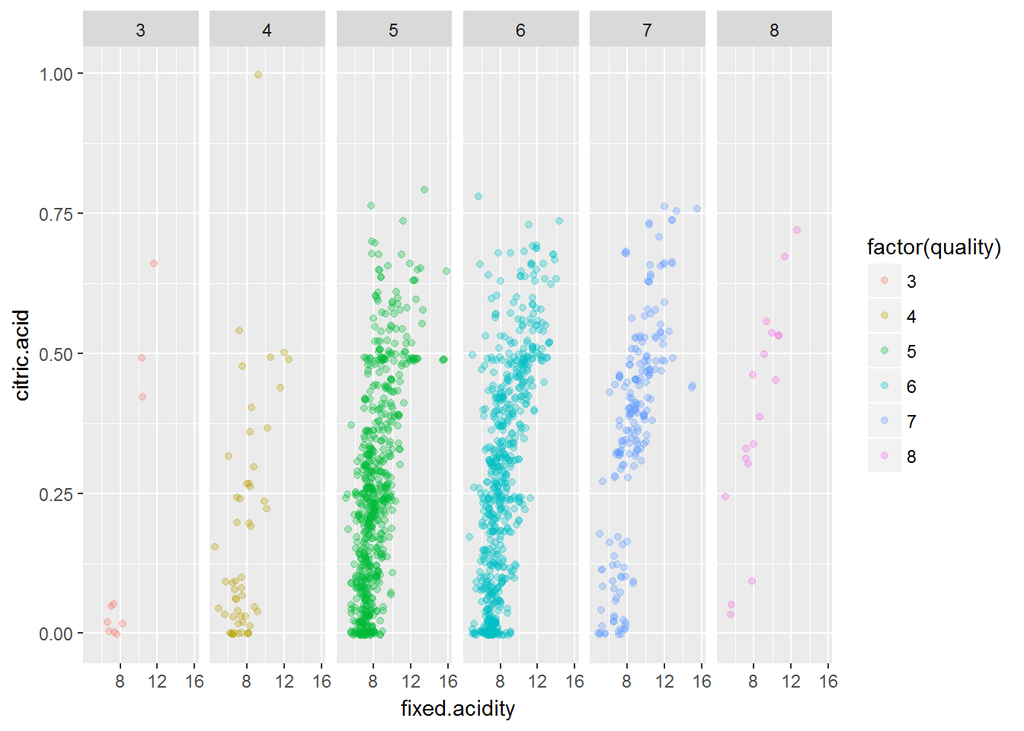

We can see a very slight trend but not overwhelming evidence of a relationship.

# Multivariate Analysis

We can see a very slight trend but not overwhelming evidence of a relationship. I expected to see a clearer picture of the relationship between these variables.

# Final Plots and Summary

### Plot One

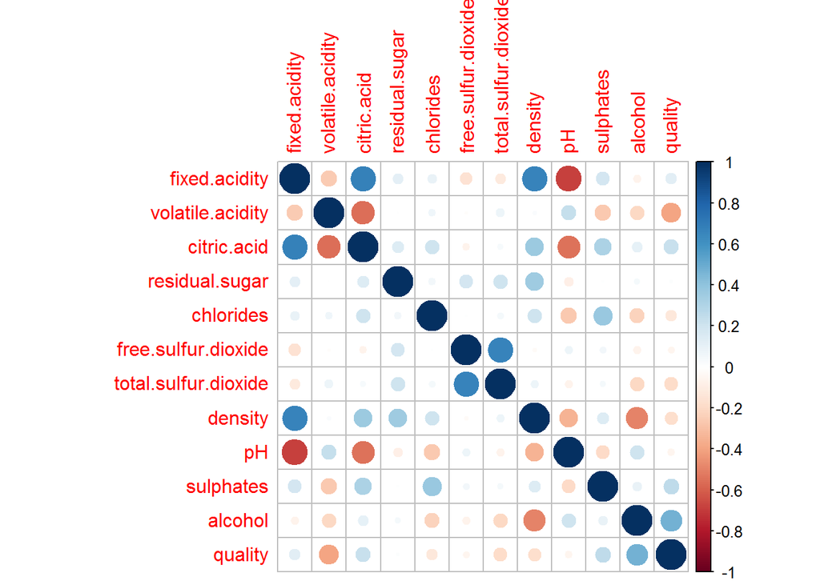

### Description One

This plot shows the correlation between all the variables. It is a good place to start to see how the variables all relate to each other. It shows us that quality has the highest positive correlation with alcohol(0.47), then sulphates(0.25), then citric acid(0.22), and finally fixed acid(0.124). It also has higher negative correlation with valatile acidity(-0.39),total sulfur dioxide(-0.185) and density(-0.175).

### Plot Two

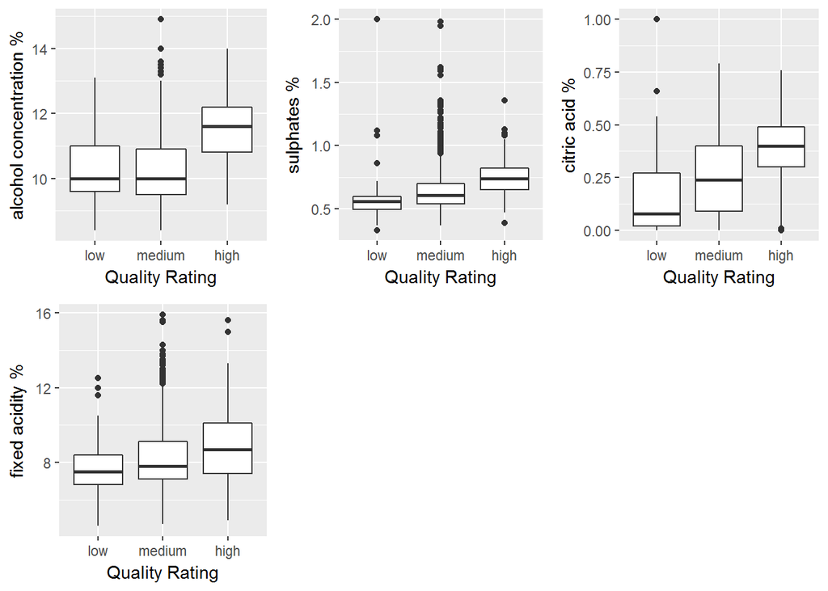

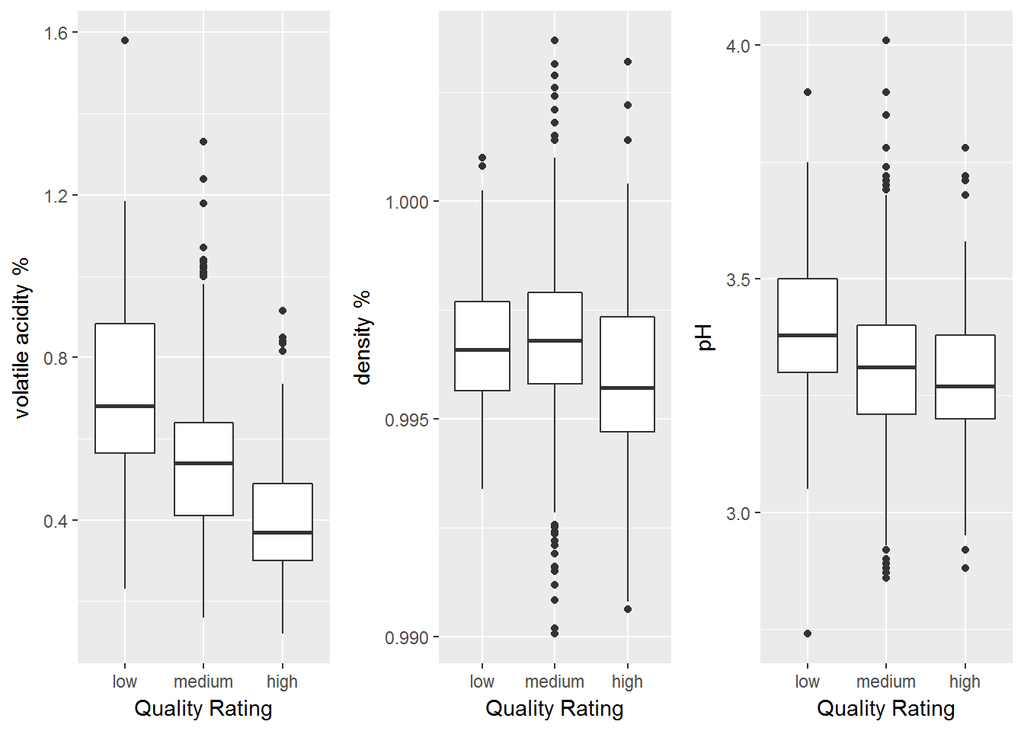

### Description Two

In these boxplots I chose to focus on those variables that either move with or against the level of quality. As we can see above the level of lcohol, sulphates, citric.acid, and fixed.acidity tend to increase as wine quality increases. Conversely, olatile.acidity, pH, and density levels tend to decrease as wine quality increases.

### Plot Three

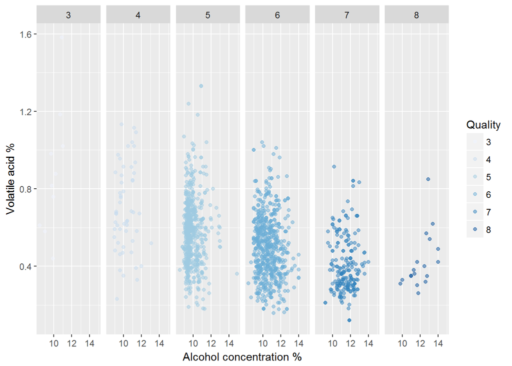

# Reflection

What really stood out to me after analyzing this data is how much nothing really stood out. While there were some slight trends here and there, overall the data was pretty spread out when comparing the quality to the different variables.

I wish there was more data surrounding what types of wines we are looking at. For example, some are very dry by nature so if somebody only likes sweeter wines, they are going to give that one a poor rating and vice versa. So if we are comparing a dry wine to a sweet wine, it makes sense that there is going to be little rhyme or reason to the ratings. If I were to pull my own data I would break it down a little further in the hopes that we could find some real correlations and trends within the different varietels.

# References

https://stackoverflow.com/questions/38412817/draw-a-trend-line-using-ggplot

https://www.r-statistics.com/2013/05/log-transformations-for-skewed-and-wide-distributions-from-practical-data-science-with-r/

https://udacity.com

https://www.r-project.org/other-docs.html

https://www.datamentor.io/r-programming/box-plot